# latrend: A Framework for Clustering Longitudinal Data

Clustering of longitudinal data is used to explore common trends among subjects over time. In this paper, we focus on cases where the sole repeated measurement of interest is numeric. Various R packages have been introduced throughout the years for identifying clusters of longitudinal patterns, summarizing the variability in trajectories between subjects in terms of one or more trends. We introduce the R package latrend as a framework for the unified application of methods for longitudinal clustering, enabling comparisons between methods with minimal coding. The package also serves as an interface to commonly used packages for clustering longitudinal data, including dtwclust, flexmix, kml, lcmm, mclust, mixAK, and mixtools. This enables researchers to easily compare different approaches, implementations, and method specifications. Furthermore, researchers can build upon the standard tools provided by the framework to quickly implement new cluster methods, enabling rapid prototyping.

true , Steffen Pauws (Tilburg University, and Philips Research) , Edwin van den Heuvel (Eindhoven University of Technology)  
2025-08-12

## 1 Introduction

In this work, we consider the case where subjects are repeatedly measured on the same variable over a period of time. This type of data is referred to as longitudinal data. In this paper, we focus on the repeated measurement of a single numeric variable, although in other applications, longitudinal measurements may be ordinal or even categorical (e.g., sequence analysis), and comprise multiple variables. No two subjects are identical, and therefore observations made across subjects may develop differently over time. Usually, longitudinal datasets are represented by a single general trend, i.e., an average representative trajectory indicating the expected change and variability over time. However, there may be structural deviations from the trend caused by observed and unobserved factors, or the distribution of random deviations is difficult to model parametrically.

Clustering longitudinal data is a practical approach for exploring or representing the variability between subjects in more detail (Hamaker 2012). Here, the variability is summarized in terms of a manageable number of common trends, which are identified in an unsupervised manner from the data using a cluster algorithm. The approach is especially useful for exploring datasets involving a large number of trajectories, where a visual inspection of the trajectories would be impractical. In essence, the data are assumed to comprise several groups, each with a different longitudinal data generating mechanism. It differs from cross-sectional clustering due to the need to account for the dependency between observations within subjects, and the possible temporal correlation in the repeated measurements.

The exploration of subgroups in longitudinal studies is of interest in many domains. Examples include recidivism behavior in criminology, the development of adolescent antisocial behavior or substance use in psychology, and medication adherence in medicine. An example application that we will demonstrate further in this paper is the exploration of the different ways in which patients with sleep apnea adhere to positive airway pressure (PAP) therapy over time. Here, therapy adherence is measured in terms of the number of hours of sleep during which the therapy is used, recorded daily. Patients exhibit different levels of adherence to the therapy, depending on many factors such as their sleep schedule, motivation, self-efficacy, and the perceived importance of therapy (Cayanan et al. 2019). Moreover, patients may exhibit a different level of change over time, depending on their initial usage and their ability to adjust to the therapy. To account for the many possibly unobserved factors involved, researchers have used longitudinal clustering to summarize the between-subject variability in terms of longitudinal patterns of therapy adherence (Babbin et al. 2015; Den Teuling et al. 2021a; Yi et al. 2022).

A number of packages have been created in R (R Core Team 2024) that can be used for clustering longitudinal data. However, for researchers analyzing a novel case study, choosing the best method or implementation is not straightforward due to the inherent exploratory nature of such an analysis. Considering that each of these packages has been created to fulfill a gap in the capabilities of other existing implementations or approaches, there is value in comparing the results for new case studies at hand. In any case, the evaluation of different approaches across packages is an activity of considerable effort, as the methods, inputs, estimation procedure, and cluster representations differ greatly between packages.

The aim of the latrend package is to facilitate the exploration of heterogeneity in a longitudinal dataset on a numeric variable of interest, through a variety of cluster methods from various fields of research in a standardized manner. The package provides a unifying framework, enabling users to specify, estimate, select, compare, and evaluate any supported longitudinal cluster method in an easy and consistent way, with minimal coding. Most importantly, users can easily compare results between different approaches, or run a simulation study. A second aim of latrend is to enable users to extend the framework with new methods or add support for other existing methods. The latrend package is available from the Comprehensive R Archive Network (CRAN) at (https://CRAN.R-project.org/package=latrend) and on GitHub at (https://github.com/niekdt/latrend).

To the best of our knowledge, such a comprehensive package does not yet exist in the context of clustering longitudinal data. The latrend package has similar aspirations as the flexmix package (Grün and Leisch 2008), which also provides an extensible framework for (multilevel) clustering. However, the scope of our package is purposefully broader, to facilitate users to apply approaches from various fields of research. Our framework is agnostic to the specification, estimation, and representation used by the methods.

The paper is organized as follows. A short overview of different approaches to clustering longitudinal data is given in Section 2. In Section 3, the design principles and high-level structure of the framework are described. The usage of the package is demonstrated in Section 4. Section 5 describes three ways in which users can implement their own cluster methods. Lastly, a summary and future steps are presented in Section 6.

## 2 Methods

We will briefly describe common general approaches to clustering longitudinal data, and the main strengths of these approaches. For brevity, we do not go into the specifics of any of the packages. We refer to the accompanying articles of these packages for further details. Starting with the aspects that all approaches have in common, let the repeated observations of the trajectory from subject $i$ be denoted by
$$\mathbf{y}_i = (y_{i1}, y_{i2}, ..., y_{iJ_i}),$$
where $y_{ij}$ is a numerical value of some variable of interest, $t_{ij}$ is the measurement time, and $J_i$ is the number of observations of trajectory $\mathbf{y}_i$ for subject $i$.

Regardless of the approach, any method for clustering longitudinal data approximates the dataset heterogeneity in terms of a set of $K$ clusters, with each cluster representing a proportion $\pi_k$ of the population, with $\pi_k > 0$ and $\sum_{k = 1}^K \pi_k = 1$. The clusters may be discovered by identifying groupings of similar subjects, based on their trajectory. Typically, a cluster method is estimated for a given number of clusters, specified by the user. By applying a cluster method for a different number of clusters, the most appropriate number of clusters can then be determined for the respective data.

Subjects are generally assumed to belong to a single cluster. Therefore, many cluster methods partition the subjects into $k$ mutually exclusive sets $I_1, I_2, ..., I_K$, where $I_k$ denotes the set of subjects to belong to cluster $k$, with $\bigcup_{k=1}^{K}I_{k}=I$. Depending on the application, it may be desirable to identify a representation for each cluster, also referred to as the cluster center, which provides a summary of the cluster. This representation may be obtained from the averaged representation of all the subjects assigned to the respective cluster, by designating a representative subject, or through the cluster representation defined by the method, if applicable.

Other cluster methods allow for overlapping clusters, commonly referred to as soft or fuzzy clustering. Here, subjects may belong to multiple clusters, with a certain degree or weight to which subjects belong to each cluster. In the case of model-based clustering (McNicholas and Murphy 2010), the clusters are represented by a mixture of statistical models, for which cluster membership is expressed as a probability. In applications where each subject is assumed to belong to one cluster, subjects are typically assigned to the cluster with the highest subject-specific posterior probability, referred to as modal assignment.

### 2.1 Cross-sectional clustering

In a cross-sectional cluster approach, also referred to as a raw-data-based approach (Liao 2005), the different observation moments are treated as separate features for a standard cluster algorithm, i.e., as if we are conducting a cross-sectional cluster analysis. In standard cluster algorithms such as $k$-means, the features are assumed to be independent, although this is generally not a strict requirement. The temporal independence assumption made in this approach yields a non-parametric representation of the trajectories. This makes it a useful approach for an exploratory analysis without any prior assumptions on the shape of the trajectories. The main limitation of this approach is that observations must be aligned between trajectories, i.e., measured at the same respective moments in time. Consequently, missing observations should be imputed.

An example of a cross-sectional approach is longitudinal $k$-means (KmL). KmL applies the $k$-means cluster algorithm directly to the observations. The cluster trajectories are determined by the averaged observations of trajectories assigned to the respective cluster. The method is implemented in the kml package by Genolini et al. (2015).

A model-based cross-sectional approach is seen in longitudinal latent profile analysis (LLPA), otherwise known as longitudinal latent class analysis (Muthén 2004). Here, Gaussian mixture modeling is used to describe each moment in time as a normally distributed random variable. A dataset with trajectories each comprising $J$ observations is thus described by $J$ random variables, each modeling the response distribution at a different moment in time. Gaussian mixture models can be estimated using, for example, the mclust package by Scrucca et al. (2016). In the simplest case, the $J$ observations are modeled as being independent and the variance is shared between clusters, but by relaxing constraints on the covariance matrix, temporal correlations and different cluster shapes can be accounted for.

### 2.2 Distance-based clustering

Distance-based cluster algorithms operate on the pairwise distance between trajectories. These methods take a distance matrix of pairwise trajectory distances as input, where the choice of the distance metric, i.e., the dissimilarity measure, is left to the user. Examples of cluster algorithms that use this approach include $k$-medoids and agglomerative hierarchical clustering.

Given the trajectories of subject $a$ and $b$, the distance metric is denoted by $d(\mathbf{y}_a, \mathbf{y}_b)$. As an example, the Euclidean distance
$$d(\mathbf{y}_a, \mathbf{y}_b) = \sqrt{\sum_{j} (y_{bj} - y_{aj})^2}.$$
may be used as the distance metric. Cross-sectional clustering is a special case of distance-based clustering where a raw-data distance metric is used.

The approach is commonly used for time series clustering, and the list of available distance metrics that have been proposed over the past decades is extensive (Aghabozorgi et al. 2015). A distance function can be specified to account for one or more temporal aspects of interest, e.g., mean level, changes over time, variability, autocorrelation, spectral components, and entropy. Many dissimilarity metrics are implemented in the dtwclust package (Sardá-Espinosa 2019).

### 2.3 Regression-based clustering

In regression-based clustering, the longitudinal dataset is modeled by a regression model comprising a mixture of submodels (Cruz-Mesía et al. 2008). It is also referred to as latent-class trajectory modeling. This approach comprises a versatile class of (semi-)parametric methods. Most importantly, the shape of the trajectories can be represented using a parametric model, requiring fewer parameters compared to a non-parametric approach. Measurements can be taken at different times between subjects, and covariates can be accounted for. Moreover, users can incorporate assumptions into the modeling of the trajectories and clusters, such as the distribution of the response variable, the within-cluster variability, and heteroskedasticity.

A straightforward example of regression-based clustering involves modeling the population as a mixture of cluster trajectory models. This is referred to as group-based trajectory modeling (GBTM) or latent-class growth analysis (LCGA). It is essentially a mixture of linear regression models, with
$$\begin{equation} \label{eqn:gbtm_y}
y_{ij} = \mathbf{x}_{ij} \mathbf{\beta}_k + \varepsilon_{ijk} \quad \textrm{for } i \in I_k,
\end{equation}$$
where $\mathbf{x}_{ij}$ is the $N \times B$ design matrix of $B$ covariates, $\mathbf{\beta}_k$ are the $B$ group-specific coefficients, and $\varepsilon_{ijk}$ is the normally distributed residual error with zero mean and constant variance $\sigma_k^2$ which may be specified to differ between clusters. The design matrix contains covariates of time, enabling the model to describe the change in response over time. External covariates can be included to further explain the dependent variable. The expected values of a trajectory, assuming the trajectory belongs to cluster $k$, is given by
$$\begin{equation}
\label{eqn:gbtm}
E(y_{ij} | C_i = k) = \mathbf{x}_{ij} \mathbf{\beta}_k.
\end{equation}$$
GBTM is available, for example, in the packages lcmm (Proust-Lima et al. 2017) and crimCV (Nielsen 2023).

A popular form of regression-based clustering that does consider within-cluster variability is growth mixture modeling (GMM) (Muthén 2004), which represents a mixture of multilevel models. Here, the within-cluster variability is modeled by allowing for subject-specific deviations from the cluster center, e.g., a deviation in the intercept. Using a linear mixed modeling approach, the trajectories for cluster $k$ are given by
$$\begin{equation}
y_{ij} = \mathbf{x}_{ij} \mathbf{\beta}_k + \mathbf{z}_{ij} \mathbf{u}_{ki} + \varepsilon_{ijk} \quad \textrm{for } i \in I_k.
\end{equation}$$
Here, $\mathbf{z}_{ij}$ is the $N \times U$ design matrix for the $U$ random effects, and $\mathbf{u}_{ki}$ are the subject-specific random coefficients for cluster $k$. The random effects are assumed to be normally distributed with mean zero and variance-covariance matrix $\Sigma_k$. The expected values of a trajectory, assuming the trajectory belongs to cluster $k$, is given by
$$\begin{equation}
\label{eqn:gmm}
E(y_{ij} | C_i = k, \mathbf{u}_{i}) = \mathbf{x}_{ij} \mathbf{\beta}_k + \mathbf{z}_{ij} \mathbf{u}_{ki}.
\end{equation}$$
GMM is available in packages such as lcmm (Proust-Lima et al. 2017), mixtools (Benaglia et al. 2009), and mixAK (Komárek 2009).

### 2.4 Feature-based clustering

In a feature-based approach, each trajectory is independently represented by a set of temporal characteristics (i.e., features, coefficients), for example, the mean, variability, and change over time (Liao 2005). The trajectories are then clustered based on the features or coefficients using a cross-sectional cluster algorithm. This can be regarded as a special case of distance-based clustering, but with a domain-tailored distance function. This approach has the advantage of allowing users to easily combine arbitrary features of interest. The approach is used, for example, by the anchored $k$-medoids algorithm provided by the akmedoids package (Adepeju et al. 2020). Here, the trajectories are represented using linear regression models, and are clustered based on the model coefficients.

Compared to the rather time-intensive regression-based clustering approach, the trajectory models only need to be estimated once. A disadvantage compared to regression-based clustering is that the reliability of the trajectory coefficients depends on the available data per trajectory. This approach therefore generally requires a greater number of observations per subject to yield similar results.

### 2.5 Identifying the number of clusters

Due to the exploratory nature of clustering, the number of clusters is typically not known in advance. Moreover, most of the cluster methods require the user to specify the number of clusters. The preferred number of clusters for the respective method can be determined by estimating the method for an increasing number of clusters, followed by comparing the solutions by means of an evaluation metric. In such a comparison for a particular method, the interpretation of the metric is consistent across the solutions, as they all originate from the same method specification.

Many metrics are available, although they may not be defined for each type of method. For example, in distance-based methods, the solutions are typically evaluated in terms of the separation between clusters. Cluster separation is measured by the distance between trajectories or cluster trajectories, e.g., using the average Silhouette width (ASW) (Rousseeuw 1987) or the Dunn index (Arbelaitz et al. 2013). In contrast, a regression-based approach typically has no notion of the distance between trajectories, but instead measures the likelihood of the overall regression model on the given data, enabling the use of likelihood-based evaluation such as the Bayesian information criterion (BIC), Akaike information criterion (AIC), or likelihood ratio test (Nest et al. 2020). Specific to cluster regression methods where the longitudinal observations are modeled at the subject level, assessing the solution in terms of the residual errors of the trajectories may be of interest. Examples of such metrics include the mean absolute error (MAE) and root mean squared error (RMSE). For probabilistic assignments these metrics may be weighted by the posterior probability of the trajectories, denoted as WMAE and WRMSE, respectively.

Overall, the preferred metric depends on the type of method under consideration and the case study domain. In the case of evaluation between different types of methods, a metric should be selected which is defined for both types of method, which may rule out many of the options. Users are advised to follow recommendations from literature for the respective method. Moreover, it is advisable to use the evaluation metric merely as guidance in identifying the preferred solution, as a trade-off between the number of clusters and the interpretability of the solution. Lastly, it is worthwhile to factor in domain knowledge into the selection of cluster solutions (Nagin et al. 2018).

### 2.6 Comparing methods

The approaches may yield considerably different results, arising from fundamental differences in the temporal representation and similarity criterion of the methods. Moreover, some approaches are more applicable to certain measurement moments, sample sizes, trajectory shapes and cluster sizes than others. To guide users towards an initial choice for a suitable approach, we have listed some of the general strengths and limitations of the different approaches in the table below. Note that even for methods of the same type of approach, results may differ depending on how the trajectories are represented, trajectory similarity is measured, or how clusters are formed. Considering that the most suitable approach or method is typically not known in advance, it is advisable to evaluate and compare the solutions between methods to identify the most suitable method for the respective case study. The resulting solutions can then be compared using an external evaluation metric.

A useful starting point in comparing the preferred solutions between methods is to evaluate the similarity between the cluster partitions. After all, if both candidate methods find a similar cluster partition, this would indicate that both methods find the same grouping despite representational differences. In contrast, if the cluster partitions are dissimilar, it may suggest that either a hybrid approach could be of interest, or that one method is preferred over the other.

The similarity between cluster partitions of two methods can be assessed using partition similarity metrics such as the adjusted Rand index (ARI) (Hubert and Arabie 1985), variance of information, or the split-join index. These metrics are applicable to any method and are even applicable when the solutions have a mismatching number of clusters. In some case studies, a ground truth may be available in the form of a reference cluster partition. Partition similarity metrics such as the ARI may then be used to identify the solution that most closely resembles the ground truth. Alternatively, one may obtain a partial ground truth by manually annotating a subset of the trajectories based on domain knowledge.

Solutions may be compared further by assessing the compactness of the clusters or the separation between clusters on a common distance metric, for example using the average Silhouette width or the Dunn index. This is useful to identify the method that is best at identifying distinct subgroups.

Summary of the general strengths and limitations of the different approaches to longitudinal clustering.

Approach

Strengths

Limitations

Cross-sectional

- Suitable for initial exploration due to no assumptions on the shape of the cluster trajectories
- Low sample size requirement
- Very fast to estimate
- Requires time-aligned trajectories of equal length
- Requires complete data
- Does not account for the temporal relation of observations

Distance-based

- Flexible in the choice of distance metric(s)
- Trajectory distance matrix only needs to be computed once
- Fast to estimate
- Distance matrix computation is not practical for a large number of trajectories
- Pairwise comparison of trajectories is more sensitive to noise
- Many distance metrics require time-aligned trajectories

Regression-based

- Low sample size requirements due to inclusion of parametric assumptions (Martin and Oertzen 2015)
- Can handle missing data
- Can handle trajectories of unequal length and variable time
- Can account for covariates
- Relatively robust to trajectories that do not fit the representation
- May be challenging to estimate (convergence problems) (Den Teuling et al. 2021b)
- Computationally intensive to estimate

Feature-based

- Temporal features only needs to be computed once
- Very fast to estimate
- Fast alternative to regression-based approach given a sufficiently large sample size (Den Teuling et al. 2021b)
- Sensitive to trajectories that do not fit the representation
- Trajectory-independent feature estimation is more sensitive to observational outliers

## 3 Software design

We begin by providing a high-level description of the framework, outlining the main functionality of the classes. A step-by-step demonstration of the framework is given in the next section. The software is built on an object-oriented paradigm using the S4 system, available in the methods package (R Core Team 2024). The framework is designed to provide a standardized way of specifying, estimating, and evaluating different longitudinal cluster methods. This is achieved by defining two interfaces: the `lcMethod` interface is used for defining the specification and estimation logic of a method. The `lcModel` interface represents the result of an estimated method. Using these two interfaces, we can then define method-agnostic estimation procedures for applying a specified method to a given dataset, yielding a method result. This estimation procedure is implemented by the `latrend()` function. For example, users can specify a growth mixture model (GMM) through a `lcMethodLcmmGMM` object, specifying the GMM and the estimation settings. The resulting estimated GMM is represented by a `lcModelLcmmGMM` object.

A key advantage of having stand-alone estimation procedures is that it ensures all methods take the same data format as input, and allows for more procedures to be implemented which automatically support all implemented methods. There are additional procedures implemented in the package, including repeated estimation via `latrendRep()`, batch estimation via `latrendBatch()`, and standard non-parametric bootstrap sampling via `latrendBoot()`.

### 3.1 Dataset input

We have selected the `data.frame` in long format as the preferred representation for longitudinal datasets. Here, each row represents an observation for a trajectory at a given time, possibly for multiple covariates. The trajectory and time of an observation are indicated in separate columns. This format can represent irregularly timed measurements, a variable number of observations per trajectory, and an arbitrary number of covariates of different types. Since not all datasets are readily available in this format, the `latrend()` estimation procedures handle data input by calling the generic `transformLatrendData()` function. Currently, this transformation is only defined for `matrix` input. Users can implement the method to add support for other longitudinal data types.

### 3.2 The `lcMethod` class

The `lcMethod` class has two purposes. The first purpose is to record the method specification, defined by the method parameters and other settings, referred to as the method arguments. The second purpose is to provide the logic for estimating the method for the specified arguments and given data. `lcMethod` objects are immutable. Users only interact with a `lcMethod` object for retrieving method arguments, or for creating a new specification with modified arguments. This functionality is provided by the base `lcMethod` class.

The base class also stores the method arguments in a list, inside the `arguments` slot. The method arguments can be of any type. The names of subclasses are prefixed by “*lcMethod*”. Subclasses can validate the model arguments against the data by overriding the `validate()` function. Due to the specific internal structure of a `lcMethod` object, constructors are defined for creating `lcMethod` objects of a specific class for a given set of arguments. In `lcMethod` implementations that are a wrapper around an existing cluster package function, the method arguments are simply passed to the package function. The required arguments and their default values are obtained from the formal function arguments of the package function at runtime.

The evaluation of the method arguments is delayed until the method estimation process. This enables a `lcMethod` object to be printed in an easily readable way, where the original argument expressions or calls are shown, instead of the evaluation result. This is useful when an argument takes on a function or complex data structure, and it reduces the memory footprint when a large set of method permutations is generated and serialized, such as in a simulation study.

The method estimation process is implemented through six generic functions: `prepareData()`, `compose()`, `validate()`, `preFit()`, `fit()`, and `postFit()`. The purpose of each step is explained in Section 5. There are several advantages to this design. Firstly, the structure enables the method estimation process to be checked at each step. Secondly, splitting the estimation logic into processing steps encourages shorter functions with clearer functionality, resulting in more readable code. Thirdly, the steps enable optimizations in the case of repeated method estimation, for which the `prepareData()` function only needs to be called once. Lastly, in case of an update to the `lcModel` post-processing step, the `postFit()` function can be applied to previously obtained `lcModel` objects.

#### Supported methods

An overview of the currently available methods that can be specified is given in the table below. The `lcMethodGCKM` class implements a feature-based approach, based on representing the trajectories through a linear mixed model specified in the lme4 package (Bates et al. 2015).

The list of currently supported methods for clustering longitudinal data, in alphabetical order. The methods in the bottom row represent generic approaches which can be adapted. Class names are prefixed by “lcMethod”.

| Class (`lcMethod`) | Method | Package |
| --- | --- | --- |
| `Akmedoids` | Anchored *k*-medoids | akmedoids (Adepeju et al. 2020) |
| `CrimCV` | Group-based trajectory modeling of count data | crimCV (Nielsen 2023) |
| `Dtwclust` | Dynamic time warping | dtwclust (Sardá-Espinosa 2019) |
| `Flexmix` | Interface to FlexMix framework | flexmix (Grün and Leisch 2008) |
| `FlexmixGBTM` | Group-based trajectory modeling | flexmix (Grün and Leisch 2008) |
| `FunFEM` | funFEM | funFEM (Bouveyron 2021) |
| `GCKM` | Feature-based clustering using growth curve modeling and *k*-means | lme4 (Bates et al. 2015) |
| `KML` | longitudinal *k*-means | kml (Genolini et al. 2015) |
| `LcmmGBTM` | Group-based trajectory modeling | lcmm (Proust-Lima et al. 2017) |
| `LcmmGMM` | Growth mixture modeling | lcmm (Proust-Lima et al. 2017) |
| `LMKM` | Feature-based clustering using linear regression and *k*-means |  |
| `MclustLLPA` | Longitudinal latent profile analysis | mclust (Scrucca et al. 2016) |
| `MixAK_GLMM` | Mixture of generalized linear mixed models | mixAK (Komárek 2009) |
| `MixtoolsGMM` | Growth mixture modeling | mixtools (Benaglia et al. 2009) |
| `MixtoolsNPRM` | Non-parametric repeated measures clustering | mixtools (Benaglia et al. 2009) |
| `MixTVEM` | Mixture of time-varying effects models |  |
| `Random` | Random partitioning |  |
| `Stratify` | Stratification rule |  |
| `Feature` | Feature-based clustering |  |

Additionally, a partitioning of trajectories can be specified without an estimation step through the `lcModelPartition` and `lcModelWeightedPartition` classes, providing trajectories with a cluster membership or membership weight, respectively.

### 3.3 The `lcModel` class

The `lcModel` class represents the estimated cluster solution. It is designed to function as any other model fitted in R. Here, the word “model” should be taken in the broadest sense of the word, where any resulting cluster partitioning represents the data, and thereby is regarded as a model of said data. Users can apply the familiar functions from the stats package (R Core Team 2024) where applicable, including the `predict()`, `plot()`, `summary()`, `fitted()`, and `residuals()` functions. Furthermore, `lcModel` objects support functions for obtaining the cluster representation, such as the cluster proportions, sizes, names, and trajectories.

The base `lcModel` class facilitates basic functionality such as providing a solution summary and providing functionality for computing predictions or fitted values. The two most important functions that characterize the class are the `predict()` and `postprob()` functions. These functions are used to derive the cluster trajectories, the posterior probabilities of the trajectories, and cluster proportions.

The base class stores information regarding the model, including the estimated `lcMethod` object, the `call` that was used to estimate the method, the date and time when the method was estimated, the total estimation time, and a text label for differentiating solutions. Users should not update the slots of the base class directly, except for the `tag` slot, which is intended as a convenient way of assigning custom meta data to the `lcModel`.

The names of subclasses are prefixed by “*lcModel*”. Subclasses generally have little need for adding new slots, as most of the functionality resides inside the class functions, such that results and statistics are computed dynamically. This enables fitted `lcModel` objects to be modified retroactively, e.g., for correcting implementation errors that are discovered at a later stage.

In the `lcModel` subclass implementations that are based on an underlying R package, the subclass serves as a wrapper around the underlying package model. The underlying model is exposed via the `getModel()` function so that users can still benefit from the specialized functionality provided by the underlying package.

### 3.4 The metric interfaces

There is a vast number of metrics available in literature. To provide access to as many metrics as possible, and to enable users to add missing metrics as needed, we define an interface for the computation of metrics. Users can replace or extend the metrics with custom implementations. To ensure a consistent output across all metrics, the output of metric functions must be scalar. Note that some metrics may be undefined for certain types of methods, in which case `NA` is returned (e.g., likelihood-based metrics such as the AIC and BIC are only defined for model-based methods). Currently, the framework supports any of the applicable metrics from the packages clusterCrit (Desgraupes 2023) and mclustcomp (You 2021). The list of supported internal and external metrics is obtained via the `getInternalMetricNames()` and `getExternalMetricNames()` functions, respectively. Metrics can be added or updated via the `defineInternalMetric()` and `defineExternalMetric()` functions.

## 4 Using the package

The goal of the analysis is to identify the common patterns of adherence and to establish the most suitable method for the data out of those considered. For brevity, the description of the package function arguments used in the demonstration below is limited to the main arguments. We refer users to the package documentation to learn more about other optional arguments.

The `PAP.adh` dataset comprises records of the weekly average hours of therapy usage of 301 patients in their first 13 weeks of therapy. Therapy usage ranges between 0 and 9.5 hours, with a mean of 4.5 hours. The `PAP.adh` dataset is represented by a `data.frame` in long format, with each row representing the observation of a patient at a specific week (1 to 13).

```r
library("latrend")
data("PAP.adh")
head(PAP.adh, n = 3)
```

```
  Patient Week UsageHours    Group
1       1    1   6.298703 Adherers
2       1    2   5.916080 Adherers
3       1    3   5.022241 Adherers
```

The `Patient` column indicates the trajectory to which the observation belongs. The `UsageHours` column represents the averaged hours of usage in the respective therapy week, denoted by the `Week` column. The true cluster membership per trajectory is indicated by the `Group` column.

Throughout the analysis, there are several occasions during which the trajectory identifier and time columns would need to be specified. Instead of passing the column names to each function, we can set the default index columns using the `options` mechanism. Keep in mind that this is only recommended during interactive use.

```r
options(latrend.id = "Patient", latrend.time = "Week")
```

We can visualize the patient trajectories using the `plotTrajectories()` function, shown in the figure below. As the ground truth is known in our synthetic example, we specified the cluster membership of the trajectories via the `cluster` argument, resulting in a stratified visualization.

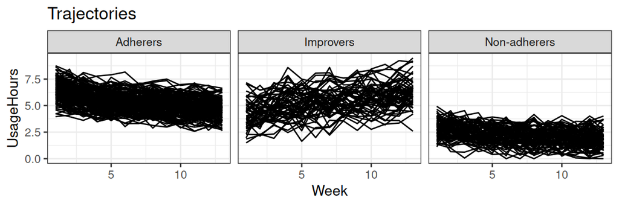

Figure 1: The trajectories from the `PAP.adh` dataset, by reference group.

```r
plotTrajectories(PAP.adh, response = "UsageHours", cluster = "Group")
```

### 4.1 Specifying methods

We first specify the methods to be evaluated. The first method of interest in this case study is KmL, selected for its flexibility in identifying patterns of any shape. The KmL method is available in the framework through the `lcMethodKML` class, which serves as a wrapper around the `kml()` function of the kml package (Genolini et al. 2015). The KmL method is specified through the `lcMethodKML()` constructor function.

```r
kmlMethod <- lcMethodKML(response = "UsageHours", nClusters = 2)
kmlMethod
```

```
lcMethodKML specifying "longitudinal k-means (KML)"
 time:           getOption("latrend.time")
 id:             getOption("latrend.id")
 nClusters:      2
 nbRedrawing:    20
 maxIt:          200
 imputationMethod:"copyMean"
 distanceName:   "euclidean"
 power:          2
 distance:       function() {}
 centerMethod:   meanNA
 startingCond:   "nearlyAll"
 nbCriterion:    1000
 scale:          TRUE
 response:       "UsageHours"
```

Note that any unspecified arguments have been set to the default values defined by the kml package. The method arguments can be accessed using the `$` or `[[` operator. Requested arguments are evaluated unless disabled by the argument `eval = FALSE`. As can be seen in the method output below, the time index column is obtained from the `options` mechanism by default.

```r
kmlMethod$time
```

```
[1] "Week"
```

```r
kmlMethod[["time", eval = FALSE]]
```

```
getOption("latrend.time")
```

Next, we specify the other methods of interest. We use a variety of approaches that are applicable to this type of data. We evaluate a feature-based approach based on LMKM as implemented in `lcMethodLMKM`, a distance-based dynamic time warping approach via `lcMethodDtwclust` based on the dtwclust package, and the regression-based approaches via the `lcMethodLcmmGBTM` and `lcMethodLcmmGMM` methods based on the lcmm package (Proust-Lima et al. 2017). We specify the distance-based approach using dynamic time warping. For LMKM, GBTM and GMM, we model the trajectories using an intercept and slope. Moreover, GBTM and GMM are specified to use a shared diagonal variance-covariance matrix. The GMM defines a random patient intercept.

```r
dtwMethod <- lcMethodDtwclust(response = "UsageHours", distance = "dtw_basic")
lmkmMethod <- lcMethodLMKM(formula = UsageHours ~ Week)
gbtmMethod <- lcMethodLcmmGBTM(fixed = UsageHours ~ Week,
  mixture = ~ Week, idiag = TRUE)
gmmMethod <- lcMethodLcmmGMM(fixed = UsageHours ~ Week,
  mixture = ~ Week, random = ~ 1, idiag = TRUE)
```

The method arguments of a `lcMethod` object cannot be modified. Instead, a new specification is created from the existing one with the updated method arguments. Any `lcMethod` object can be used as a prototype for creating a new specification with new, modified, or removed arguments using the `update()` function. As an example, if we would like to respecify KmL to identify three clusters, this can be done by updating the existing specification as follows:

```r
kml3Method <- update(kmlMethod, nClusters = 3)
```

```r
kmlMethods  <- lcMethods(kmlMethod,  nClusters = 1:6)
lmkmMethods <- lcMethods(lmkmMethod, nClusters = 1:6)
dtwMethods  <- lcMethods(dtwMethod,  nClusters = 2:6)
gbtmMethods <- lcMethods(gbtmMethod, nClusters = 1:4)
gmmMethods  <- lcMethods(gmmMethod,  nClusters = 1:4)
length(gmmMethods)
```

```
[1] 4
```

### 4.2 Fitting methods

Using the previously created method specifications, we can estimate the methods for the `PAP.adh` data. For estimating a single method, we can use the `latrend()` function. The function optionally accepts an `environment` through the `envir` argument for evaluating the method arguments within a specific environment. The output of the function is the fitted `lcModel` object.

```r
lmkm2 <- latrend(lmkmMethod, data = PAP.adh)
summary(lmkm2)
```

```
Longitudinal cluster model using lmkm
lcMethodLMKM specifying "lm-kmeans"
 time:           "Week"
 id:             "Patient"
 nClusters:      2
 center:         function (x) {    mean(x, na.rm = TRUE)}
 standardize:    `scale`
 method:         "qr"
 model:          TRUE
 y:              FALSE
 qr:             TRUE
 singular.ok:    TRUE
 contrasts:      NULL
 iter.max:       10
 nstart:         1
 algorithm:      `c("Hartigan-Wong", "Lloyd", "Forgy", "M
 formula:        UsageHours ~ Week

Cluster sizes (K=2):
          A           B
166 (55.1%) 135 (44.9%)

Number of obs: 3913, strata (Patient): 301

Scaled residuals:
    Min.  1st Qu.   Median     Mean  3rd Qu.     Max.
-2.52815 -0.67127 -0.06772  0.00000  0.54587  4.04438
```

Instead of needing to update a method prior to calling `latrend()`, the arguments to be updated can also be passed directly to `latrend()`. Here, we estimate the LMKM method for three clusters.

```r
lmkm3 <- latrend(lmkmMethod, nClusters = 3, data = PAP.adh)
```

Alternatively, we can achieve the same result by updating the previously estimated two-cluster solution.

```r
lmkm3 <- update(lmkm2, nClusters = 3)
```

#### Batch estimation

The `latrendBatch()` function estimates a list of method specifications. This is useful for evaluating a method for a range of number of clusters, as we have defined above using the `lcMethods()` function. Another use case is the improvement of model convergence and the estimation time by tuning the control parameters. Optimizing such parameters may yield considerably improved convergence or considerably reduced estimation time on larger datasets. Many of the methods have settings for the number of random starts, maximum number of iterations, and convergence criteria. However, because such control settings are specific to each method, we will not cover this.

The inputs to the `latrendBatch()` function are a list of `lcMethod` objects, and a list of datasets. The output is an `lcModels` object, representing a list of the fitted `lcModel` objects for each dataset. A seed is specified to ensure reproducibility of the examples.

```r
lmkmList <- latrendBatch(lmkmMethods, data = PAP.adh, seed = 1)
lmkmList
```

```
List of 6 lcModels with
  .name .method       seed nClusters
1     1    lmkm  762473831         1
2     2    lmkm 1762587819         2
3     3    lmkm 1463113723         3
4     4    lmkm 1531473323         4
5     5    lmkm 1922000657         5
6     6    lmkm 1985277999         6
```

When printing a `lcModels` object, the content is shown as a table of method specifications. By default, only arguments which differ between the models are shown. The table can also be obtained as a `data.frame` by calling `as.data.frame()`. We now fit the other methods in the same manner.

```r
dtwList <- latrendBatch(dtwMethods, data = PAP.adh, seed = 1)
```

For the repeated estimation of more computationally intensive methods, we can speed up the process by using parallel computation. By setting `parallel = TRUE`, the `latrendBatch()` function will use the parallel back-end of the foreach package (Microsoft and Weston 2022). To make use of this functionality, we first need to configure the parallel back-end:

```r
nCores <- parallel::detectCores(logical = FALSE)
if (.Platform$OS.type == "windows") {
  doParallel::registerDoParallel(parallel::makeCluster(nCores))
} else {
  doMC::registerDoMC(nCores)
}
```

The methods can then be estimated in parallel using:

```r
kmlList  <- latrendBatch(kmlMethods,
  data = PAP.adh, parallel = TRUE, seed = 1)
gbtmList <- latrendBatch(gbtmMethods,
  data = PAP.adh, parallel = TRUE, seed = 1)
gmmList  <- latrendBatch(gmmMethods,
  data = PAP.adh, parallel = TRUE, seed = 1)
```